# Czyszczenie i porządkowanie danych

Tomasz Przechlewski

Powiślańska Szkoła Wyższa (Kwidzyn/Poland)  
t.plata-przechlewski@psw.kwidzyn.edu.pl

21/2/2026

## Data wrangling

Data wrangling to proces **czyszczenia, porządkowania i przygotowywania danych do analizy**.

To etap, w którym „surowe” dane zamieniasz w dane gotowe do analizy statystycznej.

### Dlaczego to jest potrzebne?

Dane z badań (np. ankiety zdrowotnej) często są:

- niekompletne,
- z błędami,
- w złym formacie,
- niespójne (np. „K”, „kobieta”, „F”, „female”),
- zapisane w kilku plikach.

### Co wchodzi w skład data wrangling?

- Czyszczenie danych:
  - usuwanie duplikatów
  - obsługa braków (NA)
  - poprawianie literówek
- Transformacja:
  - zmiana formatu (np. tekst → liczba)
  - tworzenie nowych zmiennych (np. BMI)
  - przekształcanie skali (liniowa → logarytmiczna, liczbowa → nominalna)
- Filtrowanie
  - wybór tylko wybranej grupy (np. kobiety 40+)
- Łączenie danych
  - scalanie kilku plików w jeden
- Zmiana struktury
  - zmiana danych z „szerokich” na „długie”

Nawet 70–80% czasu analizy to **data wrangling**. Powinniśmy mieć to na uwadze planując badanie.

### Przykład 1 Pima Indians dataset (Pima Indians Diabetes Database)

Pima Indians dataset to jeden z najbardziej znanych zbiorów danych w statystyce i uczeniu maszynowym (rodzaj statystyki). Służy do przewidywania występowania cukrzycy typu 2 na podstawie danych klinicznych.

Zmienne (cechy):

Pregnancies – liczba przebytych ciąż

Glucose – stężenie glukozy w osoczu (po 2h w teście OGTT)

BloodPressure – ciśnienie rozkurczowe (mm Hg)

SkinThickness – grubość fałdu skórnego tricepsa (mm)

Insulin – stężenie insuliny (µU/ml)

BMI – wskaźnik masy ciała

DiabetesPedigreeFunction – wskaźnik obciążenia rodzinnego cukrzycą

Age – wiek (lata)

Outcome (zmienna zależna) – 0 → brak cukrzycy ; 1 → rozpoznana cukrzyca

W wielu zmiennych występują wartości „0”, które w rzeczywistości oznaczają brak danych (np. 0 BMI jest niemożliwe).

Duża liczba braków w niektórych zmiennych: SkinThickness, Insulin

Przykładowa analiza:

- czy istnieje zależność pomiędzy BloodPressure a BMI?
- czy coraz starsze kobiety mają większe szanse na zachorowanie na cukrzycę?

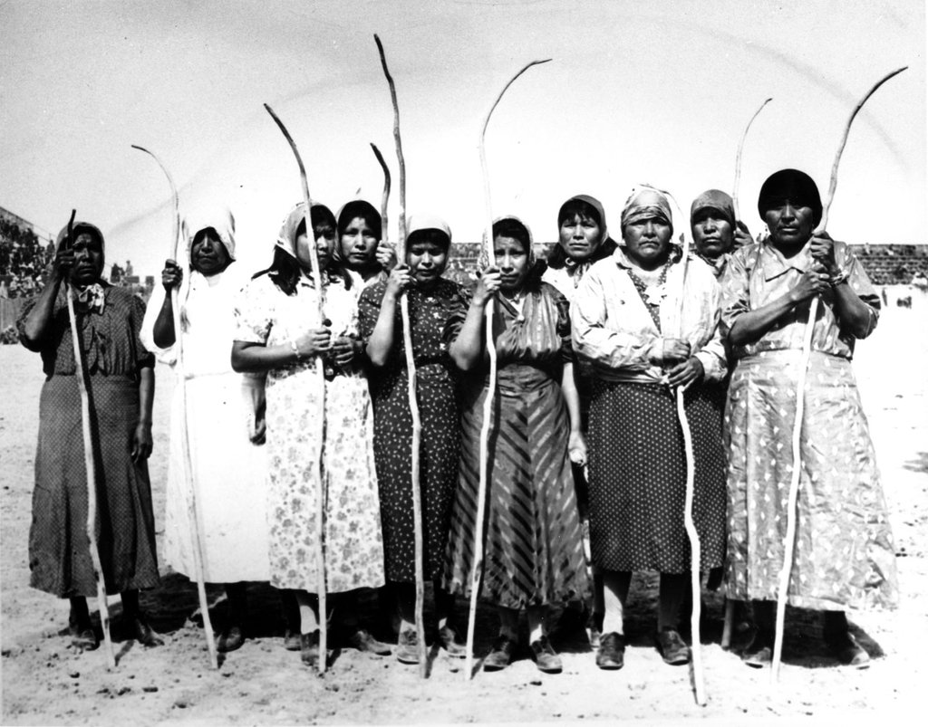

Więc idziesz po pustyni Sonora i naprzeciwko widzisz takie panie. Co robisz?

### Przykład 2: Postawa wzgl. statystyki a samoskuteczność

https://chatgpt.com/share/69994512-09bc-8002-9884-37f57a9e1861

https://docs.google.com/forms/d/1Wh-UDVFJFVPs7esU1J3tDt0xxCWdjgDlLkDdtfCC5Jc/edit

Przykładowa analiza:

- Czy ss jest różne dla kobiet i mężczyzn?
- Czy ss zależy od wieku?
- Czy istnieje zależność między pws a ss?

## Podział administracyjny Polski i Europy

System TERYT jest używany w Polsce przez GUS na przykład. W bazie BDL większość danych jest zagregowana wg systemu TERYT. NUTS to system używany przez Eurostat.

TERYT = https://pl.wikipedia.org/wiki/TERYT

TERC = System identyfikatorów i nazw jednostek podziału administracyjnego

```
TERYT id:  00        00      000     - 7 digits
            1.        2.       3.
```

1. province/województwo (00, 02, …, 32) – 2 digits; z jakiś powodów tylko cyfry parzyste
2. county/powiat (00, 01, …, 59 - powiat; 60, …, 99 - city-county/miasto na prawach powiatu) - 2 digits
3. community/gmina albo part of community/części gmin (000……, gdzie ostatni znak oznacza rodzaj jednostki) - 3 digits

NUTS

```
NUTS id : 00 00      0        00      00     000     (12 digits)
           1. 2.     3.        4.      5.      6.    (6 groups)
```

1. macroregion/makroregion (01, 02, …, 07)
2. province/województwo (00, 02, …, 32)
3. region/region (1, 2)
4. subregion/podregion (00, 01, …, 73)
5. County (powiatu (00, 01, …, 59 - powiat; 60, …, 99 - miasto na prawach powiatu) - 2 digits
6. community/gmina or part of community/części gmin (000……, gdzie ostatni znak stanowi symbol rodzaju jednostki) - 3 digits

https://stat.gov.pl/statystyka-regionalna/jednostki-terytorialne/klasyfikacja-nuts/klasyfikacja-nuts-w-polsce/

## Typy formaty i struktury danych

**Typ danych** = zbiór wartości, jaką może przyjąć **zmienna**; typ danych określa, jakie operacje można wykonywać na **zmiennej**

Typy danych: data/czas, liczba, napis, prawda/fałsz

**Struktura danych** to sposób organizacji danych w pamięci komputera.

**Format danych** to sposób organizacji, zapisu i interpretacji danych, który określa, jak informacje są przechowywane i odczytywane przez systemy komputerowe. Potocznie rodzaj pliku z danymi, często związany z określoną aplikacją, która potrafi ten plik „otworzyć” i zapisać.

**Excel**: struktura danych ogólnie skomplikowana; podstawowe struktura = dwuwymiarowa tabela (wiersze/kolumny); **typ danych** określony na poziomie komórki.

**Relacyjne bazy danych**: struktura danych zaprojektowana do efektywnego przechowywania i przetwarzania ogromych zbiorów danych. Baza danych składa się z połączonych (logicznie) tabel.

**SQL**: standardowy język zapytań relacyjnych baz danych. Ponieważ współcześnie ogromne zbiorami danych są powszechne, wiele programów implementuje zwykle częściowo SQL, np Excel (`filter`, `select`, `join`).

Format danych: excel, ale też są inne formaty:

- CSV,
- Json,
- XML,

CSV = prosty format w którym dane są podzielone na wiersze (zwykle obserwacje) oraz kolumny (zwykle zmienne); wiersze i kolumny są oddzielone umownym znakiem. Opcjonalny pierwszy wiersz może być interpretowany jako nagłówek zawierający nazwy zmiennych. Przykładowo zbiór **Pima Indians dataset** w formacie CSV wygląda tak

```
pregnancies;glucose;bloodpress;skin;insulin;bmi;DiabetesPedigreeFunction;Age;outcome
6;148;72;35;0;33.6;0.627;50;1
1;85;66;29;0;26.6;0.351;31;0
8;183;64;0;0;23.3;0.672;32;1
```

Każdy program od Excela do kosztującego pierdzilion `$$$` SPSSa potrafi wczytać plik CSV.

Problem kropki dziesiętnej

Wartość brakująca (missing value / Non-available value)

Format długi i szeroki (long/wide format; PivotTable)

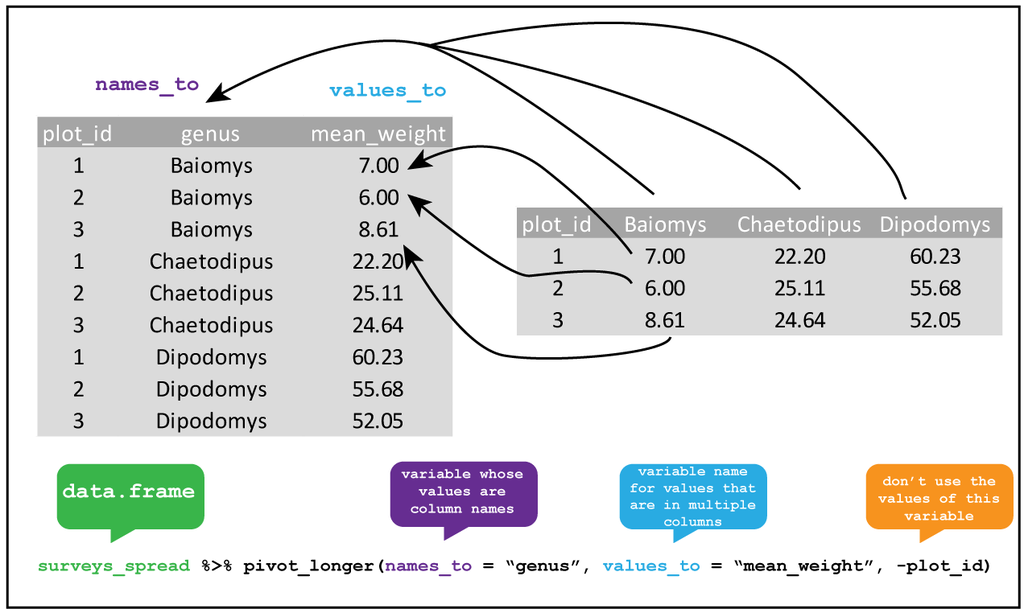

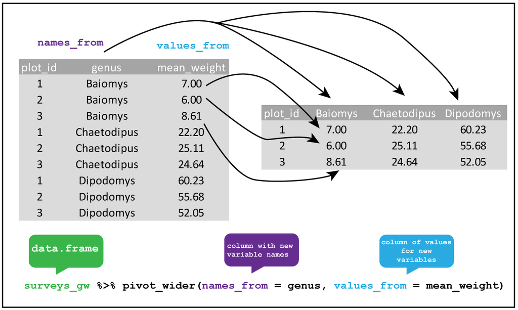

Łączenie tabel

```
+-------+--------------------+    +-------+-------------------+
| teryt | liczba-mieszkańców |   | teryt | liczba-samochodów  |
+-------+--------------------+    +-------+-------------------+

+-------+--------------------+    +-------+-------------------+
| teryt | nazwa-powiatu      |    | teryt | konsumpcja paliw  |
+-------+--------------------+    +-------+-------------------+
```

Wydrukować nazwę powiatu i obliczony wskaźnik liczby samochodów na mieszkańca (per capita) + przeciętne zużycie paliwa na samochód i mieszkańca

https://data.europa.eu/apps/data-visualisation-guide/wide-versus-long-data

## Przetwarzanie danych (aka programy statystyczne)

Arkusze: Excel, Google sheets, LibreOffice

Desktopowe systemy statystyczne, np. SPSS, Stata

Przetwarzanie w chmurze: Azure (microsoft) https://docs.microsoft.com/pl-pl/azure/architecture/data-guide/technology-choices/r-developers-guide

AWS https://aws.amazon.com/blogs/opensource/getting-started-with-r-on-amazon-web-services/

Google https://cloud.google.com/solutions/running-r-at-scale

Programy open source: R, gretl, jamovi

## Zamiast excela

- R i RStudio (prezentacja)
- Jamovi (prezentacja)

ChatGPT: Czy R jest lepszy od Excela do analiz statystycznych?

https://chatgpt.com/share/699939ce-9770-8002-a3bb-ab1e7ce1b29b